# 3주차패키지

**#CHAPTER1#**  
#문제0번

```r
library(tidyverse)
library(data.table)
library(gridExtra)
setwd('C:\\Users\\User\\Desktop\\P-SAT\\3주차패키지')
data<-fread("data.csv")
test<-fread("test.csv")
```

#문제1번  
‘bmi(bmi 지수)’ 변수를 numeric 자료형으로 바꾸고, NA값을 mean imputation으로 채움

```r
data$bmi<-data$bmi %>% as.numeric()
data[]<-lapply(data,function(x){
  x[is.na(x)]<-mean(x,na.rm=TRUE)
  x})
data$hypertension<-as.integer(data$hypertension)
data$heart_disease<-as.integer(data$heart_disease)
data$stroke<-as.integer(data$stroke)
str(data)
```

```
## Classes 'data.table' and 'data.frame':   4087 obs. of  12 variables:
##  $ id               : num  9046 51676 31112 60182 1665 ...
##  $ gender           : chr  "Male" "Female" "Male" "Female" ...
##  $ age              : num  67 61 80 49 79 74 69 59 78 81 ...
##  $ hypertension     : int  0 0 0 0 1 1 0 0 0 1 ...
##  $ heart_disease    : int  1 0 1 0 0 1 0 0 0 0 ...
##  $ ever_married     : chr  "Yes" "Yes" "Yes" "Yes" ...
##  $ work_type        : chr  "Private" "Self-employed" "Private" "Private" ...
##  $ Residence_type   : chr  "Urban" "Rural" "Rural" "Urban" ...
##  $ avg_glucose_level: num  229 202 106 171 174 ...
##  $ bmi              : num  36.6 28.8 32.5 34.4 24 ...
##  $ smoking_status   : chr  "formerly smoked" "never smoked" "never smoked" "smokes" ...
##  $ stroke           : int  1 1 1 1 1 1 1 1 1 1 ...
##  - attr(*, ".internal.selfref")=<externalptr>
```

#문제2번  
문자형(character) 변수를 명목형 변수(factor)로 바꿈

```r
sapply(data,class)
```

```
##                id            gender               age      hypertension
##         "numeric"       "character"         "numeric"         "integer"
##     heart_disease      ever_married         work_type    Residence_type
##         "integer"       "character"       "character"       "character"
## avg_glucose_level               bmi    smoking_status            stroke
##         "numeric"         "numeric"       "character"         "integer"
```

```r
data[]<-lapply(data,function(x){
  if(is.character(x)){
    as.factor(x)}
  else x})
str(data)
```

```
## Classes 'data.table' and 'data.frame':   4087 obs. of  12 variables:
##  $ id               : num  9046 51676 31112 60182 1665 ...
##  $ gender           : Factor w/ 3 levels "Female","Male",..: 2 1 2 1 1 2 1 1 1 1 ...
##  $ age              : num  67 61 80 49 79 74 69 59 78 81 ...
##  $ hypertension     : int  0 0 0 0 1 1 0 0 0 1 ...
##  $ heart_disease    : int  1 0 1 0 0 1 0 0 0 0 ...
##  $ ever_married     : Factor w/ 2 levels "No","Yes": 2 2 2 2 2 2 1 2 2 2 ...
##  $ work_type        : Factor w/ 5 levels "children","Govt_job",..: 4 5 4 4 5 4 4 4 4 4 ...
##  $ Residence_type   : Factor w/ 2 levels "Rural","Urban": 2 1 1 2 1 1 2 1 2 1 ...
##  $ avg_glucose_level: num  229 202 106 171 174 ...
##  $ bmi              : num  36.6 28.8 32.5 34.4 24 ...
##  $ smoking_status   : Factor w/ 4 levels "formerly smoked",..: 1 2 2 3 2 2 2 4 4 2 ...
##  $ stroke           : int  1 1 1 1 1 1 1 1 1 1 ...
##  - attr(*, ".internal.selfref")=<externalptr>
```

#문제3번  
id’ 변수를 제거

```r
data<-subset(data,select=-id) %>% as.data.frame()
str(data)
```

```
## 'data.frame':    4087 obs. of  11 variables:
##  $ gender           : Factor w/ 3 levels "Female","Male",..: 2 1 2 1 1 2 1 1 1 1 ...
##  $ age              : num  67 61 80 49 79 74 69 59 78 81 ...
##  $ hypertension     : int  0 0 0 0 1 1 0 0 0 1 ...
##  $ heart_disease    : int  1 0 1 0 0 1 0 0 0 0 ...
##  $ ever_married     : Factor w/ 2 levels "No","Yes": 2 2 2 2 2 2 1 2 2 2 ...
##  $ work_type        : Factor w/ 5 levels "children","Govt_job",..: 4 5 4 4 5 4 4 4 4 4 ...
##  $ Residence_type   : Factor w/ 2 levels "Rural","Urban": 2 1 1 2 1 1 2 1 2 1 ...
##  $ avg_glucose_level: num  229 202 106 171 174 ...
##  $ bmi              : num  36.6 28.8 32.5 34.4 24 ...
##  $ smoking_status   : Factor w/ 4 levels "formerly smoked",..: 1 2 2 3 2 2 2 4 4 2 ...
##  $ stroke           : int  1 1 1 1 1 1 1 1 1 1 ...
```

#문제4번  
타겟(stoke)값 별로 범주형 변수의 분포 시각화 및 해석  
[stroke1과 stroke0를 비교했을때, gender와 residence_type에는 별로 차이 없어보이고, 그 외에것들에서는 조금씩의 차이를 보이고 있다.]

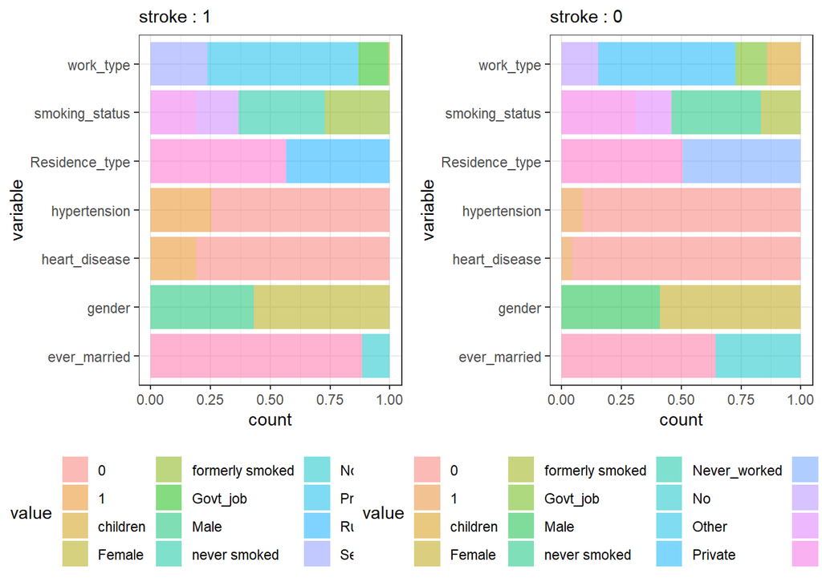

```r
is.integer = function(x){
  class(x)=="integer"
}
data<-data %>% mutate_if(is.integer,as.factor)
strokeone<-data %>% select(where((is.factor))) %>% gather(key='variable', value='value',-stroke) %>% filter(stroke==1) %>% ggplot(aes(x=variable,fill=value)) + geom_bar(position = 'fill',alpha=0.5) + coord_flip() + labs(title="stroke : 1") + theme_bw() + theme(legend.position = "bottom",plot.title = element_text(size=11))
strokezero<-data %>% select(where((is.factor))) %>% gather(key='variable', value='value',-stroke) %>% filter(stroke==0) %>% ggplot(aes(x=variable,fill=value)) + geom_bar(position = 'fill',alpha=0.5) + coord_flip() + labs(title="stroke : 0") + theme_bw() + theme(legend.position = "bottom",plot.title = element_text(size=11))
grid.arrange(strokeone,strokezero,ncol=2)
```

#문제5번  
타겟(stoke)값 별로 수치형 변수의 분포 시각화 및 해석  
[stroke1과 2에서 둘다 bmi의 max density가 제일 높음을 알 수 있고, stroke1에 비해 stroke0에 avg_glucose_level의 max density가 조금 더 높다.]

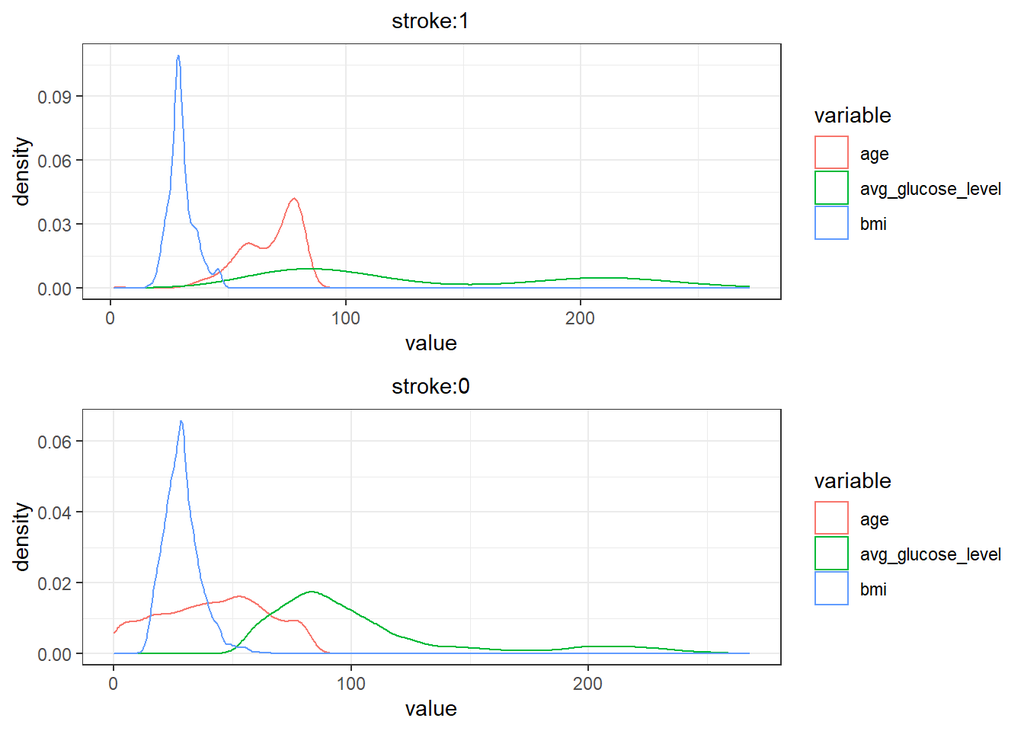

```r
strokeone2<-data %>% select(where((is.numeric)),stroke) %>% gather(key='variable', value='value',-stroke) %>% filter(stroke==1) %>% ggplot(aes(x=value,color=variable))+labs(title='stroke:1')+geom_density()+theme_bw() + theme(plot.title = element_text(size=11,hjust=0.5))

strokezero2<-data %>% select(where((is.numeric)),stroke) %>% gather(key='variable', value='value',-stroke) %>% filter(stroke==0) %>% ggplot(aes(x=value,color=variable))+labs(title='stroke:0')+geom_density()+theme_bw() + theme(plot.title = element_text(size=11,hjust=0.5))

grid.arrange(strokeone2,strokezero2,nrow=2)
```

#문제6번  
타겟 변수와 범주형 변수에 대한 카이스퀘어 독립성 검정을 진행

```r
cate_var<-select(data,where(is.factor),-stroke) %>% colnames()
re_cate<-data.frame(cate_var,chi=rep(NA,7))
for(i in 1:7){
  dt<-table(as_vector(data[,cate_var[i]]),data$stroke)
  chi<-chisq.test(dt)
  if(chi$p.value > 0.05){
    re_cate$chi[i]='accept'
  }else{
    re_cate$chi[i]='denied'
  }
}
re_cate
```

```
##         cate_var    chi
## 1         gender accept
## 2   hypertension denied
## 3  heart_disease denied
## 4   ever_married denied
## 5      work_type denied
## 6 Residence_type accept
## 7 smoking_status denied
```

#문제7번  
카이스퀘어 독립성 검정에서 가설을 기각하지 못한 범주형 변수를 제거

```r
data<-select(data,-c(gender,Residence_type))
```

#문제8번  
train data에서 했던 전처리 방법들을 사용하여 전처리

```r
str(test)
```

```
## Classes 'data.table' and 'data.frame':   1023 obs. of  12 variables:
##  $ id               : int  56669 58202 13861 38047 69160 47306 47167 38829 58631 72366 ...
##  $ gender           : chr  "Male" "Female" "Female" "Female" ...
##  $ age              : num  81 50 52 65 59 58 77 82 73 76 ...
##  $ hypertension     : int  0 1 1 0 0 0 1 0 1 0 ...
##  $ heart_disease    : int  0 0 0 0 0 0 0 0 0 0 ...
##  $ ever_married     : chr  "Yes" "Yes" "Yes" "Yes" ...
##  $ work_type        : chr  "Private" "Self-employed" "Self-employed" "Private" ...
##  $ Residence_type   : chr  "Urban" "Rural" "Urban" "Rural" ...
##  $ avg_glucose_level: num  186 167 233 101 212 ...
##  $ bmi              : chr  "29" "30.9" "48.9" "28.2" ...
##  $ smoking_status   : chr  "formerly smoked" "never smoked" "never smoked" "formerly smoked" ...
##  $ stroke           : int  1 1 1 1 1 1 1 1 1 1 ...
##  - attr(*, ".internal.selfref")=<externalptr>
```

```r
test$bmi<-test$bmi %>% as.numeric()
test[]<-lapply(test,function(x){
  x[is.na(x)]<-mean(x,na.rm=T)
  x
})
test$id<-as.integer(test$id)
test$hypertension<-as.integer(test$hypertension)
test$heart_disease<-as.integer(test$heart_disease)
test$stroke<-as.integer(test$stroke)
test[]<-lapply(test,function(x){
  if(is.character(x)){
    as.factor(x)}
  else x})
test[]<-lapply(test,function(x){
  if(is.integer(x)){
    as.factor(x)}
  else x})
str(test)
```

```
## Classes 'data.table' and 'data.frame':   1023 obs. of  12 variables:
##  $ id               : Factor w/ 1023 levels "163","170","298",..: 801 826 197 525 976 647 643 539 836 1018 ...
##  $ gender           : Factor w/ 2 levels "Female","Male": 2 1 1 1 2 2 1 1 2 2 ...
##  $ age              : num  81 50 52 65 59 58 77 82 73 76 ...
##  $ hypertension     : Factor w/ 2 levels "0","1": 1 2 2 1 1 1 2 1 2 1 ...
##  $ heart_disease    : Factor w/ 2 levels "0","1": 1 1 1 1 1 1 1 1 1 1 ...
##  $ ever_married     : Factor w/ 2 levels "No","Yes": 2 2 2 2 2 1 2 2 2 2 ...
##  $ work_type        : Factor w/ 5 levels "children","Govt_job",..: 4 5 5 4 4 4 5 4 5 4 ...
##  $ Residence_type   : Factor w/ 2 levels "Rural","Urban": 2 1 2 1 1 1 2 1 2 2 ...
##  $ avg_glucose_level: num  186 167 233 101 212 ...
##  $ bmi              : num  29 30.9 48.9 28.2 29.2 ...
##  $ smoking_status   : Factor w/ 4 levels "formerly smoked",..: 1 2 2 1 1 4 2 2 2 4 ...
##  $ stroke           : Factor w/ 2 levels "0","1": 2 2 2 2 2 2 2 2 2 2 ...
##  - attr(*, ".internal.selfref")=<externalptr>
```

```r
test<-select(test,-c(id,gender,Residence_type))
str(test)
```

```
## Classes 'data.table' and 'data.frame':   1023 obs. of  9 variables:
##  $ age              : num  81 50 52 65 59 58 77 82 73 76 ...
##  $ hypertension     : Factor w/ 2 levels "0","1": 1 2 2 1 1 1 2 1 2 1 ...
##  $ heart_disease    : Factor w/ 2 levels "0","1": 1 1 1 1 1 1 1 1 1 1 ...
##  $ ever_married     : Factor w/ 2 levels "No","Yes": 2 2 2 2 2 1 2 2 2 2 ...
##  $ work_type        : Factor w/ 5 levels "children","Govt_job",..: 4 5 5 4 4 4 5 4 5 4 ...
##  $ avg_glucose_level: num  186 167 233 101 212 ...
##  $ bmi              : num  29 30.9 48.9 28.2 29.2 ...
##  $ smoking_status   : Factor w/ 4 levels "formerly smoked",..: 1 2 2 1 1 4 2 2 2 4 ...
##  $ stroke           : Factor w/ 2 levels "0","1": 2 2 2 2 2 2 2 2 2 2 ...
##  - attr(*, ".internal.selfref")=<externalptr>
```

**#CHAPTER2#**  
#문제0번  
Catboost 모델의 특성 및 대표적인 파라미터에 대해 간단히 설명  
[Catboost는 의사결정트리에서 Gradient Boosting을 위한 알고리즘으로 특징은 오버피팅 감소와 범주형피처지원을 한다.대표적인 파라미터에는 트리 깊이, 학습률 등이 있다.]

#문제1번  
expand.grid를 사용하여 데이터프레임 만들기

```r
library(catboost)
library(caret)
library(MLmetrics)
logloss_cb<-expand.grid(depth=c(4,6,8),iterations=c(100,200),logloss=NA)
logloss_cb
```

```
##   depth iterations logloss
## 1     4        100      NA
## 2     6        100      NA
## 3     8        100      NA
## 4     4        200      NA
## 5     6        200      NA
## 6     8        200      NA
```

#문제2번  
Catboost에 대해 depth와 iteration 파라미터 튜닝을 위한 grid search 5-fold CV를 진행

```r
set.seed(1234)
cf<-createFolds(data$stroke,k=5,list=FALSE)
cf
```

[output not shown]

[output cut: 96 more lines]

```r
for(i in 1:6){
  temp<-NULL
  catrunningtime<-NULL
  for(k in 1:5){
    cv_data<-data[which(cf==k),]
    cv_test<-data[which(cf==k),]
    data_pool<-catboost.load_pool(data=cv_data[names(cv_data)!="stroke"],label=as.double(cv_data$stroke))
    test_pool<-catboost.load_pool(data=cv_test[names(cv_test)!="stroke"],label=as.double(cv_data$stroke))
    start=Sys.time()
    parameter<-list(loss_function='Logloss',random_seed=1234,iterations=logloss_cb[i,2],depth=logloss_cb[i,1],custom_loss='Logloss')
    cat<-catboost.train(learn_pool=data_pool,test_pool=test_pool,params=parameter)
    catrunningtime<-c(catrunningtime,Sys.time()-start)
    test_error<-read.table("catboost_info/test_error.tsv",sep="\t",header=T)
    temp<-c(temp,test_error[nrow(test_error),'Logloss'])
  }
  logloss_cb[i,'logloss']=min(temp)
  print(min(catrunningtime))
}
```

[output not shown]

[output cut: 4641 more lines]

```r
logloss_cb
```

```
##   depth iterations    logloss
## 1     4        100 0.12939167
## 2     6        100 0.12436487
## 3     8        100 0.11689935
## 4     4        200 0.08406320
## 5     6        200 0.06154489
## 6     8        200 0.05006100
```

#문제3번  
logloss_cb에서 가장 낮은 logloss 값의 행을 출력

```r
logloss_cb[which.min(logloss_cb$logloss),]
```

```
##   depth iterations  logloss
## 6     8        200 0.050061
```

```r
data_pool_again<-catboost.load_pool(data=data[names(data)!="stroke"],label=as.double(data$stroke))
test_pool_again<-catboost.load_pool(data=data[names(data)!="stroke"],label=as.double(data$stroke))
parameter<-list(loss_function='Logloss',random_seed=1234,iterations=200,depth=8,custom_loss='Logloss')
catT<-catboost.train(learn_pool=data_pool_again,test_pool=test_pool_again,params=parameter)
```

[output not shown]

[output cut: 189 more lines]

```r
test_error<-read.table("catboost_info/test_error.tsv",sep="\t",header=T)
test_error[nrow(test_error),'Logloss']
```

```
## [1] 0.07555585
```

**#CHAPTER3#**  
#문제1번  
수치형 변수(age, avg_glucose_level, bmi)에 대해 scale 함수로 정규화 스케일링

```r
library(factoextra)
library(cluster)

data_scale<-select(data,where(is.numeric))
data_scale<-scale(data_scale)
```

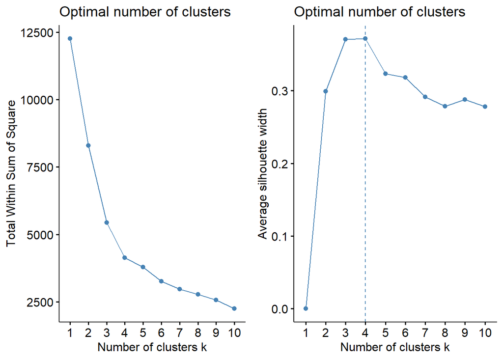

```r
fviz1<-fviz_nbclust(data_scale,kmeans,method='wss')
fviz2<-fviz_nbclust(data_scale,kmeans,method='silhouette')
grid.arrange(fviz1,fviz2,ncol=2)
```

#문제3번  
K-means 클러스터링을 한 후 시각화

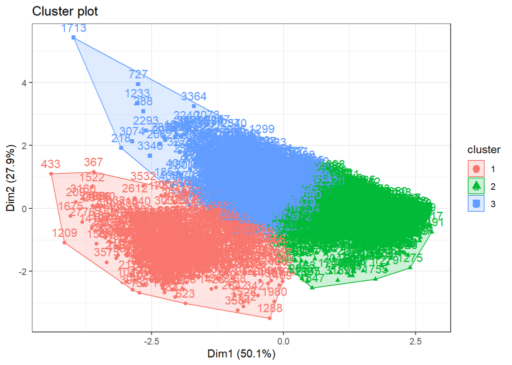

```r
set.seed(1234)
k_means<-kmeans(data_scale,centers=3,nstart=1,iter.max=30)
clustering<-fviz_cluster(k_means,data_scale)+theme_bw()
clustering
```

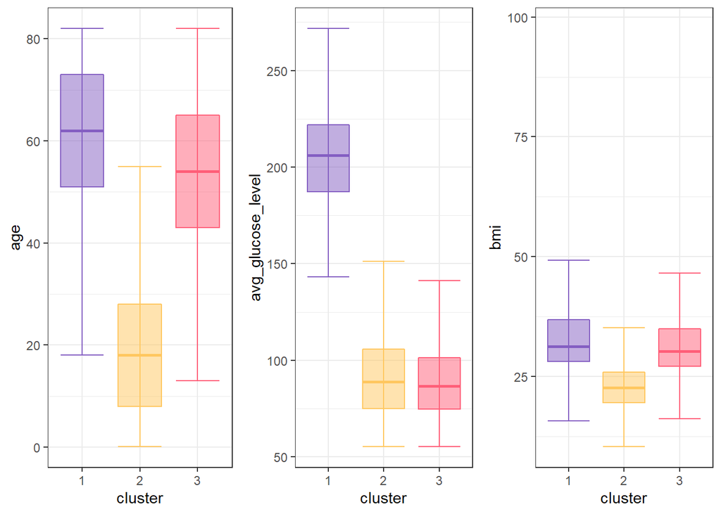

```r
Bp<-select(data,where(is.numeric))
Bp<-mutate(Bp,cluster=k_means$cluster)
Bp1<-Bp %>% ggplot(aes(x=factor(cluster),y=age))+geom_boxplot(outlier.shape=NA,alpha=0.5,fill=c('#845ec2', '#ffc75f', '#ff5e78'),color=c('#845ec2', '#ffc75f', '#ff5e78'))+stat_boxplot(geom='errorbar',color=c('#845ec2', '#ffc75f', '#ff5e78'))+labs(x='cluster')+theme_bw()
Bp2<-Bp %>% ggplot(aes(x=factor(cluster),y=avg_glucose_level))+geom_boxplot(outlier.shape=NA,alpha=0.5,fill=c('#845ec2', '#ffc75f', '#ff5e78'),color=c('#845ec2', '#ffc75f', '#ff5e78'))+stat_boxplot(geom='errorbar',color=c('#845ec2', '#ffc75f', '#ff5e78'))+labs(x='cluster')+theme_bw()
Bp3<-Bp %>% ggplot(aes(x=factor(cluster),y=bmi))+geom_boxplot(outlier.shape=NA,alpha=0.5,fill=c('#845ec2', '#ffc75f', '#ff5e78'),color=c('#845ec2', '#ffc75f', '#ff5e78'))+stat_boxplot(geom='errorbar',color=c('#845ec2', '#ffc75f', '#ff5e78'))+labs(x='cluster')+theme_bw()
grid.arrange(Bp1,Bp2,Bp3,ncol=3)
```